# NFL Losers Pool 2021 Exploration

Jordan Hutchings

08/09/2021

Our annual NFL losers pool runs by each entrant having to pick one team per week. The objective is to pick one team to lose each week, if your team wins, you are out of the pool. The catch is that once a team is picked it cannot be picked again.

I am taking a fairly simple approach to making my picks this year. Download and use the NFL forecast data from [FiveThirtyEight](https://projects.fivethirtyeight.com/2021-nfl-predictions/games/) to optimize my picks to give the best probability of lasting deep into the season.

## Visualizations

Below we can see a heatmap of all the win probabilities throughout the season. Teams like Houston, and Washington have a low likelihood of winning in many games in the season. This motivates our problem as we can only pick them each once. The teams are ordered by average likelihood of winning, we can see Houston, Detroit, and Jacksonville are the three lowest teams. There is an opportunity to out play my competitors by picking these teams in the best possible week, i.e. holding off until Week 4 to pick Houston.

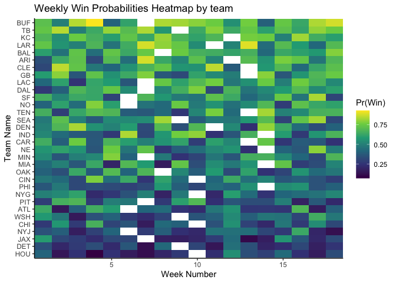

Below is a plot of the choice set of underdogs in each game. We can see there is a finite set of picks per week, with each week having differing probabilities. Ideally, we are looking for the path through these points that minimizes our chances of losing from the competition.

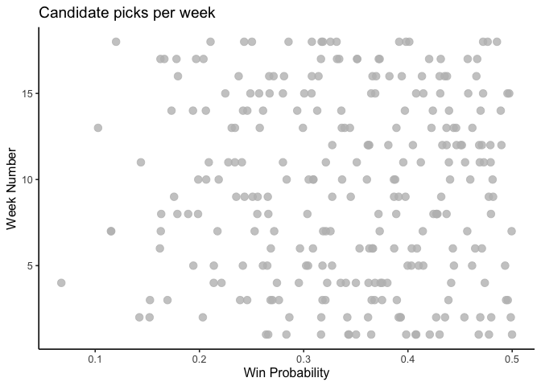

## Different approaches to consider

Approaches:  
1. Pick the lowest team by week, starting in the first week.  
2. Pick the lowest win probability across all weeks.  
3. Pick the team-week pairing with the greatest opportunity cost. In other words, if the team isn’t picked, how much of a percentage is given up.

Each of the above approaches allow for future discounting. I.e.
$$Pr(Win | Week = w) = Pr(Win) * \beta^{(w - \underline{w})}$$
where $\underline{w}$ is the start week.

Comparison of approaches

| Week | Approach 1 Team | Approach 1 ProbWin | Approach 2 Team | Approach 2 ProbWin | Approach 3 Team | Approach 3 ProbWin |
| --- | --- | --- | --- | --- | --- | --- |
| 6 | WSH | 0.269 | WSH | 0.269 | WSH | 0.269 |
| 7 | DET | 0.115 | DET | 0.115 | DET | 0.115 |
| 8 | MIA | 0.163 | MIA | 0.163 | MIA | 0.163 |
| 9 | JAX | 0.176 | JAX | 0.176 | JAX | 0.176 |
| 10 | ATL | 0.218 | ATL | 0.218 | ATL | 0.218 |
| Mean |  | 0.188 |  | 0.188 |  | 0.188 |
| SD |  | 0.058 |  | 0.058 |  | 0.058 |

## Discounting future games

We have been working off a $\beta = 1$ for each model. Below are the changes from using different values of $\beta$. Future discounting will place a higher weight on upcoming weeks. This will not change the By Week model but will have an impact on the By Probability and By Oppertunity Cost. The overall average probability of winning a game will increase as we are discounting future games. What matters now though is how much more probability we are shifting away from future weeks and to upcoming weeks. Therefore, we should no longer evaluate from the average risk per week, and instead the likelihood of reaching a given week.

## Calculating probability of making a given week

Since the game outcomes are binary we can also calculate the proportion of times we reach a given week as the following, recall $Pr(w_i)$ is the probability of the pick winning in week $i$, or losing in week $i$.

$$Pr(W \leq w) = \Pi_{i = 1}^w (1 - Pr(w_i))$$

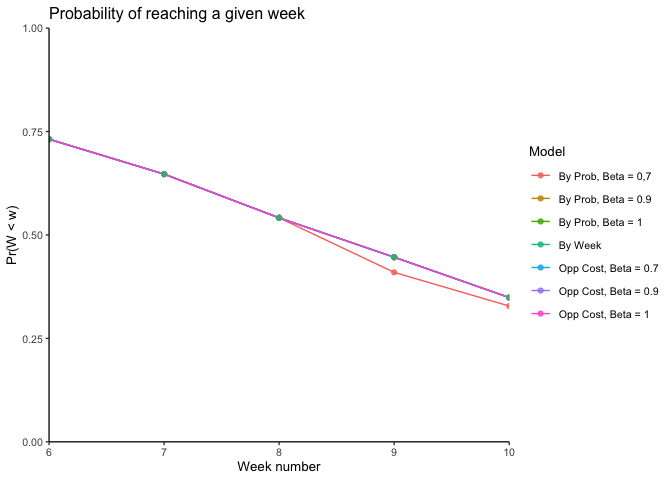

Likelihood of reaching a given week by model

| Week | Opp Cost, Beta = 1 | Opp Cost, Beta = 0.9 | Opp Cost, Beta = 0.7 | By Prob, Beta = 1 | By Prob, Beta = 0.9 | By Prob, Beta = 0,7 | By Week |
| --- | --- | --- | --- | --- | --- | --- | --- |
| 6 | 0.73 | 0.73 | 0.73 | 0.73 | 0.73 | 0.73 | 0.73 |
| 7 | 0.65 | 0.65 | 0.65 | 0.65 | 0.65 | 0.65 | 0.65 |
| 8 | 0.54 | 0.54 | 0.54 | 0.54 | 0.54 | 0.54 | 0.54 |
| 9 | 0.45 | 0.45 | 0.45 | 0.45 | 0.45 | 0.41 | 0.45 |
| 10 | 0.35 | 0.35 | 0.35 | 0.35 | 0.35 | 0.33 | 0.35 |

Note:  
Percentages represent the likelihood of reaching a given week based on the picks from each model.

Weekly Picks by Model

| Week | OC, Beta = 1 Team | OC, Beta = 1 ProbWin | OC, Beta = 0.9 Team | OC, Beta = 0.9 ProbWin | OC, Beta = 0.7 Team | OC, Beta = 0.7 ProbWin | By Week Team | By Week ProbWin |
| --- | --- | --- | --- | --- | --- | --- | --- | --- |
| 6 | WSH | 0.269 | WSH | 0.269 | WSH | 0.269 | WSH | 0.269 |
| 7 | DET | 0.115 | DET | 0.115 | DET | 0.115 | DET | 0.115 |
| 8 | MIA | 0.163 | MIA | 0.163 | MIA | 0.163 | MIA | 0.163 |
| 9 | JAX | 0.176 | JAX | 0.176 | JAX | 0.176 | JAX | 0.176 |
| 10 | ATL | 0.218 | ATL | 0.218 | ATL | 0.218 | ATL | 0.218 |
| Mean |  | 0.188 |  | 0.188 |  | 0.188 |  | 0.188 |
| SD |  | 0.058 |  | 0.058 |  | 0.058 |  | 0.058 |

## Dumbbell plot

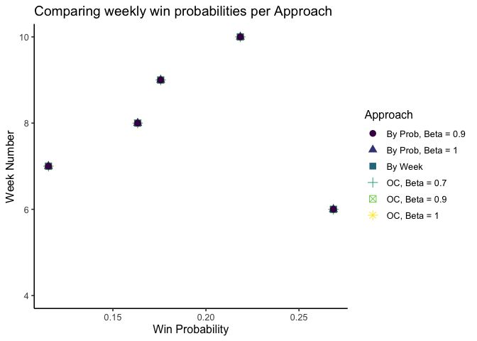

## Alterative weeks for optimal team picks

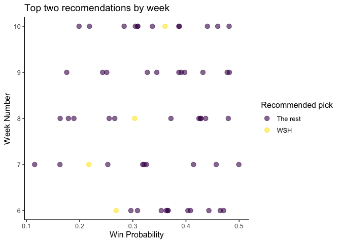

## What is the next best possible pick?

If we remove the optimal pick from our choice set, what is the next best pick? This is done so I can consider picking two different teams per week to hedge my bets.

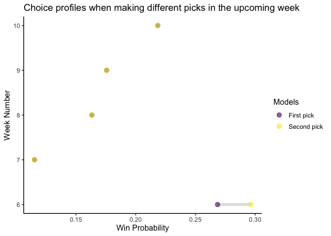

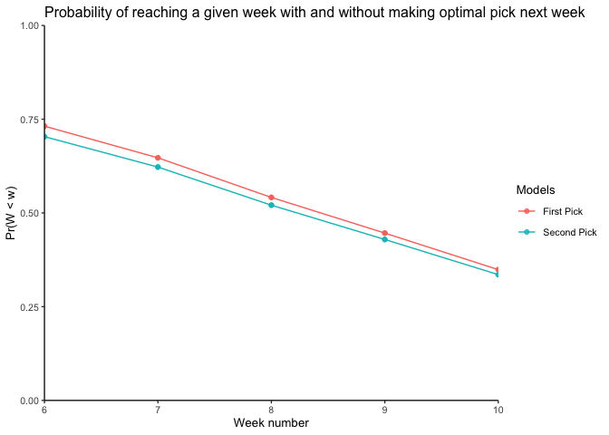

Recommended sets of picks

| Week | Optimal Pick Pick | Optimal Pick ProbWin | Next Best Pick | Next Best ProbWin |
| --- | --- | --- | --- | --- |
| 6 | WSH | 0.269 | PHI | 0.296 |
| 7 | DET | 0.115 | DET | 0.115 |
| 8 | MIA | 0.163 | MIA | 0.163 |
| 9 | JAX | 0.176 | JAX | 0.176 |
| 10 | ATL | 0.218 | ATL | 0.218 |
| Mean |  | 0.188 |  | 0.194 |
| SD |  | 0.058 |  | 0.068 |

### Showing pick profiles on choice set

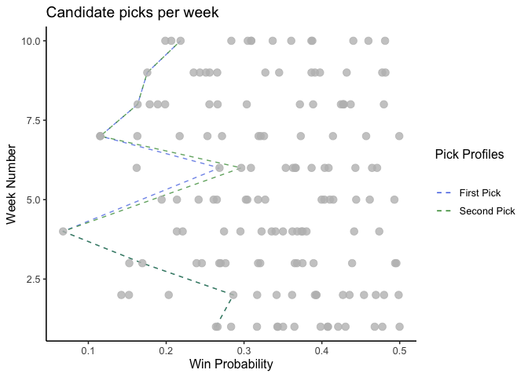

## Todos

- Make the choice plot with paths of optimal picks include picks from first N weeks.
- Make two sets of past picks for each stream of picks